# MA50258 Lab 1: Solutions

# Packages

Below is the list of packages that we will use in this lab.

```r
library(tidyverse)
library(janitor) # to clean names in a data frame
library(kableExtra) # for nicer tables
library(ggplot2)
```

# Gapminder data set

This data set was introduced in [Section 2.3](https://github.bath.ac.uk/pages/kai21/MA50258-lecture-notes/02-intro-tidyverse.html#sec-gapminder-data) of the lecture notes.

The `gapminder` tibble contains a dataset of economic social indicators such as gross domestic product (gdp) per capita, population and life expectancy of many countries over the period from 1952 to 2007 in increments of 5 years.

The data frame `gapminder` has 1704 rows and 6 variables:

- `country` A factor with 142 levels (eg 142 countries in the data set)
- `continent` A factor with 5 levels
- `year` An integer vector with years ranging from 1952 to 2007 in increments of 5 years.
- `lifeExp` life expectancy at birth, in years
- `pop` Total population
- `gdpPercap` GDP per capita (US dollars, inflation-adjusted)

The data can be loaded into `R` using the following command:

```r
library(gapminder)
library(janitor)
gapminder <- clean_names(gapminder)
```

Have a quick glimpse of the data:

```r
glimpse(gapminder)
```

```
## Rows: 1,704
## Columns: 6
## $ country    <fct> "Afghanistan", "Afghanistan", "Afghanistan", "Afghanistan",…
## $ continent  <fct> Asia, Asia, Asia, Asia, Asia, Asia, Asia, Asia, Asia, Asia,…
## $ year       <int> 1952, 1957, 1962, 1967, 1972, 1977, 1982, 1987, 1992, 1997,…
## $ life_exp   <dbl> 28.801, 30.332, 31.997, 34.020, 36.088, 38.438, 39.854, 40.…
## $ pop        <int> 8425333, 9240934, 10267083, 11537966, 13079460, 14880372, 1…
## $ gdp_percap <dbl> 779.4453, 820.8530, 853.1007, 836.1971, 739.9811, 786.1134,…
```

Note that each row in `gapminder` refers to an specific country in a specific year.

# Questions

## Instructions

1. To answer the following questions, simply fill in the code chunks with your own code.
2. You should use the `dplyr` verbs introduced in [Chapter 2](https://github.bath.ac.uk/pages/kai21/MA50258-lecture-notes/02-intro-tidyverse.html) of the lecture notes as well as the `ggplot` commands introduced in [Chapter 3](https://github.bath.ac.uk/pages/kai21/MA50258-lecture-notes/03-intro-ggplot.html) of the lecture notes.
3. Once you complete your answers, knit the corresponding Rmarkdown (`.Rmd`) document to produce an HTML file. The name of the HTML file should be Lab1.html.
4. If the answer is a data frame then you can turn it into a table using the following command.

```r
gapminder %>%
  slice_head(n =6) %>%
     kable(caption = "First six rows of the gapminder data base",
           digits  = 2) %>%
      kable_styling(bootstrap_options = "striped",
                    full_width        = F )
```

First six rows of the gapminder data base

| country | continent | year | life_exp | pop | gdp_percap |
| --- | --- | --- | --- | --- | --- |
| Afghanistan | Asia | 1952 | 28.80 | 8425333 | 779.45 |
| Afghanistan | Asia | 1957 | 30.33 | 9240934 | 820.85 |
| Afghanistan | Asia | 1962 | 32.00 | 10267083 | 853.10 |
| Afghanistan | Asia | 1967 | 34.02 | 11537966 | 836.20 |
| Afghanistan | Asia | 1972 | 36.09 | 13079460 | 739.98 |
| Afghanistan | Asia | 1977 | 38.44 | 14880372 | 786.11 |

## Question 1

Find the 10 countries with lowest GDP per capita:

1. In the whole data base
2. In 1977
3. In Africa in 1977

Display each result in a table.

```r
# Your code answer here
q1a <- gapminder %>% arrange(gdp_percap) %>% distinct(country, .keep_all = TRUE) %>% slice(1:10)
q1a
```

```
## # A tibble: 10 × 6
##    country           continent  year life_exp      pop gdp_percap
##    <fct>             <fct>     <int>    <dbl>    <int>      <dbl>
##  1 Congo, Dem. Rep.  Africa     2002     45.0 55379852       241.
##  2 Lesotho           Africa     1952     42.1   748747       299.
##  3 Guinea-Bissau     Africa     1952     32.5   580653       300.
##  4 Eritrea           Africa     1952     35.9  1438760       329.
##  5 Myanmar           Asia       1952     36.3 20092996       331
##  6 Burundi           Africa     1952     39.0  2445618       339.
##  7 Ethiopia          Africa     1952     34.1 20860941       362.
##  8 Cambodia          Asia       1952     39.4  4693836       368.
##  9 Malawi            Africa     1952     36.3  2917802       369.
## 10 Equatorial Guinea Africa     1952     34.5   216964       376.
```

```r
q1b <- filter(.data = gapminder, year == "1977") %>% arrange(gdp_percap) %>% slice(1:10)
q1b
```

```
## # A tibble: 10 × 6
##    country    continent  year life_exp      pop gdp_percap
##    <fct>      <fct>     <int>    <dbl>    <int>      <dbl>
##  1 Myanmar    Asia       1977     56.1 31528087       371
##  2 Mozambique Africa     1977     42.5 11127868       502.
##  3 Eritrea    Africa     1977     44.5  2512642       506.
##  4 Cambodia   Asia       1977     31.2  6978607       525.
##  5 Burundi    Africa     1977     45.9  3834415       556.
##  6 Ethiopia   Africa     1977     44.5 34617799       557.
##  7 Liberia    Africa     1977     43.8  1703617       640.
##  8 Bangladesh Asia       1977     46.9 80428306       660.
##  9 Malawi     Africa     1977     43.8  5637246       663.
## 10 Rwanda     Africa     1977     45    4657072       670.
```

```r
q1c <- filter(.data = gapminder, year == "1977", continent == "Africa") %>% arrange(gdp_percap) %>% distinct(country, .keep_all = TRUE) %>%  slice(1:10)
q1c
```

```
## # A tibble: 10 × 6
##    country      continent  year life_exp      pop gdp_percap
##    <fct>        <fct>     <int>    <dbl>    <int>      <dbl>
##  1 Mozambique   Africa     1977     42.5 11127868       502.
##  2 Eritrea      Africa     1977     44.5  2512642       506.
##  3 Burundi      Africa     1977     45.9  3834415       556.
##  4 Ethiopia     Africa     1977     44.5 34617799       557.
##  5 Liberia      Africa     1977     43.8  1703617       640.
##  6 Malawi       Africa     1977     43.8  5637246       663.
##  7 Rwanda       Africa     1977     45    4657072       670.
##  8 Zimbabwe     Africa     1977     57.7  6642107       686.
##  9 Mali         Africa     1977     41.7  6491649       686.
## 10 Burkina Faso Africa     1977     46.1  5889574       743.
```

```r
### Lecturer's solution
#gapminder
#  slice_min(gdp_Percap, n = 10) |>
#  select(country, continent, year, gdp_Percap) |>
#  kable(caption = "Countries with overall lowest GDP per capita", digit = 2,
#        col.names = c("Country","Continent","year","GDP per capita")) |> kable_styling(bootstrap_options = "striped", full_width = F)
```

## Question 2

Use `group_by` and `summarise` to find the average and median GDP per capita in each continent in 2007. Also find the corresponding difference between mean and median (which is an indication of skewness). Display the results in a table.

```r
# Your code answer here
q2 <- filter(.data = gapminder, year == "2007") %>%
  group_by(continent) %>%
    summarise(
      mean = mean(gdp_percap),
      median = median(gdp_percap)
  ) %>%  mutate("difference(skewness)" = mean - median) %>%
kable(caption = "GDP per capita in 2007",
      digits = 2,
      col.names = c("Continent", "Mean", "Median", "Difference   (skewness)")) %>%
  kable_styling(bootstrap_options = "striped",
                full_width = F
  )
q2
```

GDP per capita in 2007

| Continent | Mean | Median | Difference (skewness) |
| --- | --- | --- | --- |
| Africa | 3089.03 | 1452.27 | 1636.77 |
| Americas | 11003.03 | 8948.10 | 2054.93 |
| Asia | 12473.03 | 4471.06 | 8001.96 |
| Europe | 25054.48 | 28054.07 | -2999.58 |
| Oceania | 29810.19 | 29810.19 | 0.00 |

## Question 3

Display a scatter plot of GDP per capita (x) against life expectancy (y) in 2007 but differentiating countries in Europe with a different colour than the rest of the world. You should label the axes appropriately as well as produce informative labels for the colours.

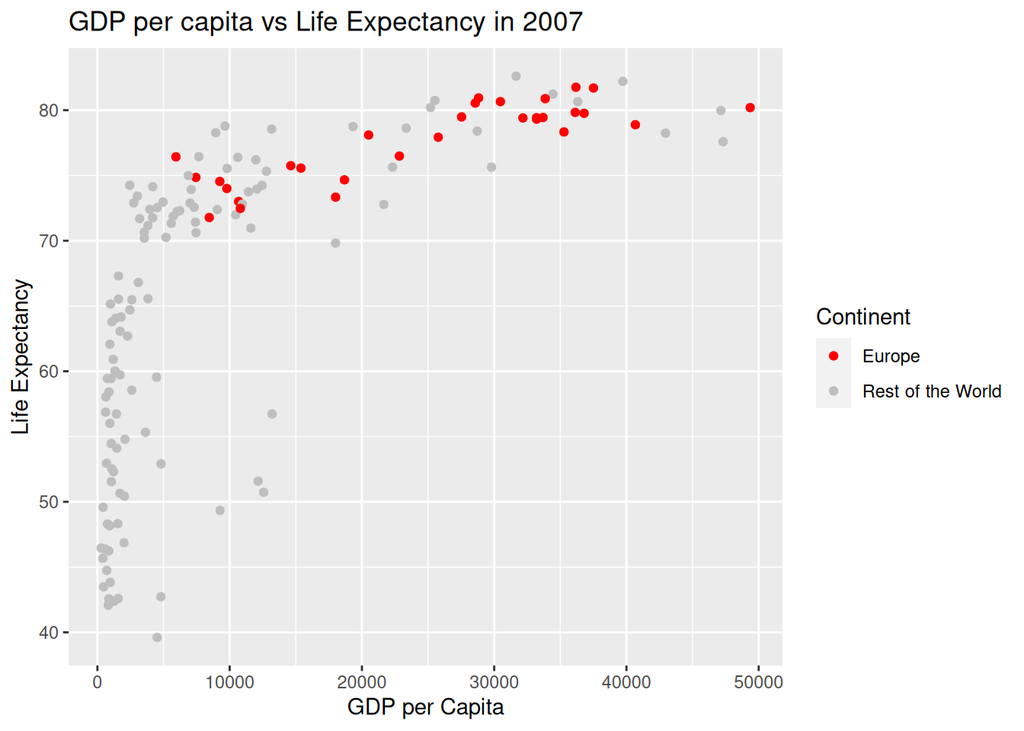

```r
# Your code answer here
ggplot(data <- gapminder %>%
         filter(year == 2007) %>%
         mutate(continent = ifelse(continent == "Europe", "Europe", "Rest of the World")),
       mapping = aes(x = gdp_percap,
                     y = life_exp)) +
  geom_point(mapping = aes(colour = continent)) +
  scale_colour_manual(values = c("Europe" = "red",
                                 "Rest of the World" = "grey")) +
  labs(x = "GDP per Capita",
       y = "Life Expectancy") +
  ggtitle("GDP per capita vs Life Expectancy in 2007") +
  labs(colour = "Continent")
```

## Question 4

Use `facet_grid` to display separate scatter plots of GDP per capita (x) against life expectancy (y) in 2007 corresponding to different continents. You should label the axes appropriately

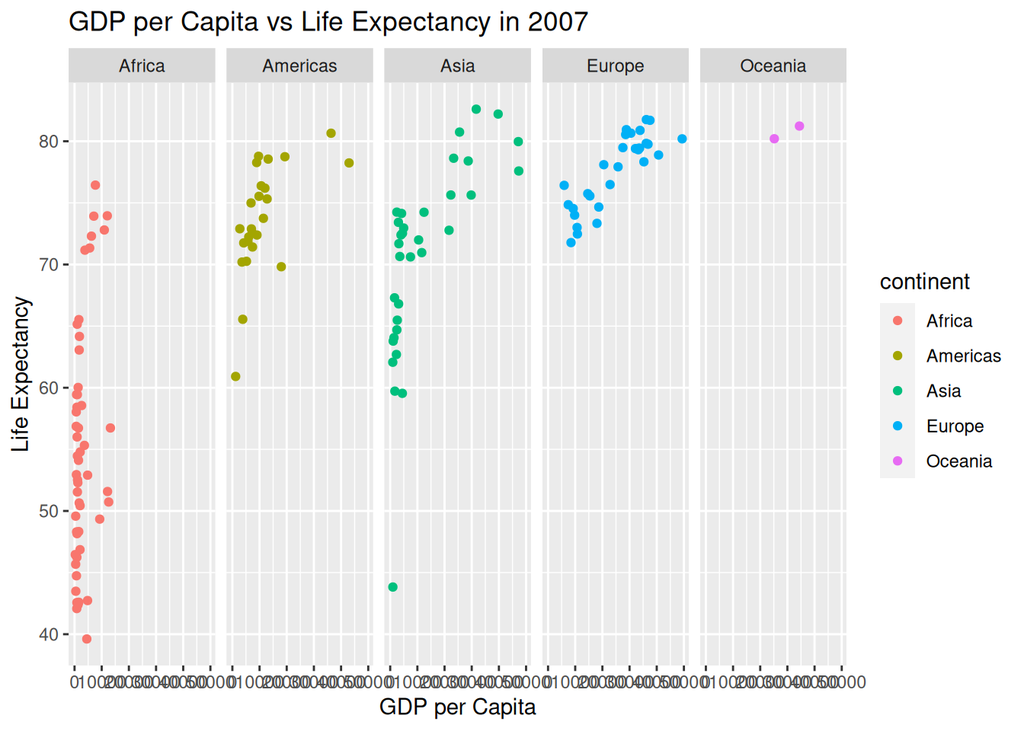

```r
# Your code answer here
ggplot(data = gapminder %>%
         filter(year == 2007),
       mapping = aes(x = gdp_percap,
                     y = life_exp)) +
  geom_point(mapping = aes(colour = continent)) +
  labs(x = "GDP per Capita", y = "Life Expectancy") +
  ggtitle("GDP per Capita vs Life Expectancy in 2007") +
  facet_grid(~continent)
```